# Urban Institute Data Visualization Specialist Interview Assignment

Alice Feng

### Exploring disparities in student transportation

```r
require(sqldf)
require(ggplot2)
require(ggmap)

setwd('C:/Users/Alice/Desktop/Urban Data Viz Assignment')
data <- read.csv("data-viz-assignment-data.csv")
```

```r
str(data)
```

```
## 'data.frame':    450 obs. of  25 variables:
##  $ id                         : Factor w/ 450 levels "1500000US110010001001",..: 1 2 3 4 5 6 7 8 9 10 ...
##  $ id2                        : num  1.1e+11 1.1e+11 1.1e+11 1.1e+11 1.1e+11 ...
##  $ geography                  : Factor w/ 450 levels "Block Group 1, Census Tract 1, District of Columbia, District of Columbia",..: 1 180 336 410 28 29 207 353 418 47 ...
##  $ families_w_under18_belowpov: int  0 0 0 0 0 0 9 0 0 0 ...
##  $ families_w_under18_abovepov: int  157 81 106 131 0 85 61 87 11 89 ...
##  $ grade_1_5_white            : int  119 18 62 79 0 10 34 42 0 86 ...
##  $ grade_1_5_two              : int  0 0 0 0 0 0 0 0 0 0 ...
##  $ grade_1_5_other            : int  0 0 0 0 0 0 0 0 0 0 ...
##  $ grade_1_5_Haw_PI           : int  0 0 0 0 0 0 0 0 0 0 ...
##  $ grade_1_5_asian            : int  0 0 50 0 0 6 0 0 0 0 ...
##  $ grade_1_5_Am_ind           : int  0 0 0 0 0 0 0 0 0 0 ...
##  $ grade_1_5_black            : int  0 0 0 0 0 0 0 15 0 0 ...
##  $ grade_1_5_Hisp             : int  45 0 0 0 0 0 0 0 0 0 ...
##  $ tractce                    : int  100 100 100 100 201 202 202 202 202 300 ...
##  $ blkgrpce                   : int  1 2 3 4 1 1 2 3 4 1 ...
##  $ statefp                    : int  11 11 11 11 11 11 11 11 11 11 ...
##  $ population                 : int  1343 1384 1163 1000 3916 1196 813 1053 2363 1384 ...
##  $ dis_rating_above_6         : num  0.357 0.541 0.24 0.318 0.577 ...
##  $ latitude_school            : num  38.9 38.9 38.9 38.9 38.9 ...
##  $ longitude_school           : num  -77.1 -77.1 -77.1 -77.1 -77.1 ...
##  $ school_id                  : num  1.1e+11 1.1e+11 1.1e+11 1.1e+11 1.1e+11 ...
##  $ charter                    : Factor w/ 2 levels "No","Yes": 1 1 1 1 1 1 1 1 1 1 ...
##  $ school_name                : Factor w/ 34 levels "ACHIEVEMENT PREPARATORY PCS ELEMENTARY",..: 14 14 14 14 14 14 14 14 14 29 ...
##  $ hi_grade                   : int  5 5 5 5 5 5 5 5 5 5 ...
##  $ lo_grade                   : Factor w/ 4 levels "1","4","KG","PK": 4 4 4 4 4 4 4 4 4 4 ...
```

How many blocks and tracts are in this dataset?

```r
length(unique(data$id))
```

```
## [1] 450
```

```r
length(unique(data$id2))
```

```
## [1] 450
```

```r
length(unique(data$tractce))
```

```
## [1] 179
```

```r
length(unique(data$blkgrpce))
```

```
## [1] 6
```

How many schools are in this dataset and how many blocks do they each have?

```r
table(data$school_name)
```

```
##
##      ACHIEVEMENT PREPARATORY PCS ELEMENTARY
##                                          26
##                                 BANCROFT ES
##                                          11
##                                    BRENT ES
##                                          37
##           CENTER CITY BRIGHTWOOD CAMPUS PCS
##                                          18
##     CENTER CITY CONGRESS HEIGHTS CAMPUS PCS
##                                          21
##             CENTER CITY PETWORTH CAMPUS PCS
##                                          17
##                 CENTER CITY SHAW CAMPUS PCS
##                                           7
##                                CLEVELAND ES
##                                           7
##                          D C  BILINGUAL PCS
##                                           9
##        D C  PREP EDGEWOOD MIDDLE CAMPUS PCS
##                                          11
##                                    EATON ES
##                                           5
##  ELSIE WHITLOW STOKES COMMUNTIY FREEDOM PCS
##                                          16
##                                   HEARST ES
##                                           6
##                             HYDE ADDISON ES
##                                          14
##                                   JANNEY ES
##                                           6
##                                      KEY ES
##                                           5
##                         KIPP DC PROMISE PCS
##                                          51
##                    KIPP DC WILL ACADEMY PCS
##                                           9
##                                LAFAYETTE ES
##                                          10
## LATIN AMERICA MONTESSORI BILINGUAL LAMB PCS
```

[output cut: 14 more lines]

```
##                                          18
##                                 SHEPHERD ES
##                                           6
##                                 STODDERT ES
##                                          13
##                                  THOMSON ES
##                                          10
##                                   TUBMAN ES
##                                          10
##                           TWO RIVERS PCS ES
##                                           9
##                      WASHINGTON YU YING PCS
##                                          13
##                                     WEST EC
##                                           8
```

### Explore distribution of driving distances

```r
summary(data$dis_rating_above_6)
```

```
##    Min. 1st Qu.  Median    Mean 3rd Qu.    Max.
## 0.05341 0.30621 0.50895 0.63992 0.87566 2.02036
```

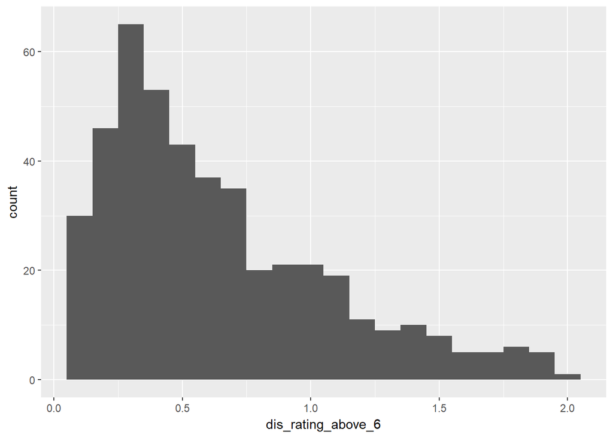

```r
ggplot(data, aes(dis_rating_above_6)) + geom_histogram(binwidth = 0.1)
```

Distribution is right skewed. Half of the blocks have less than 0.5mi driving distance on average. No apparent outliers.

### Explore demographic variables

```r
summary(data[4:13])
```

```
##  families_w_under18_belowpov families_w_under18_abovepov grade_1_5_white
##  Min.   :  0.00              Min.   :  0.0               Min.   :  0.00
##  1st Qu.:  0.00              1st Qu.: 54.0               1st Qu.:  0.00
##  Median :  0.00              Median : 88.0               Median :  0.00
##  Mean   : 28.22              Mean   :101.4               Mean   : 12.32
##  3rd Qu.: 37.75              3rd Qu.:143.8               3rd Qu.: 11.00
##  Max.   :302.00              Max.   :623.0               Max.   :212.00
##  grade_1_5_two    grade_1_5_other   grade_1_5_Haw_PI grade_1_5_asian
##  Min.   : 0.000   Min.   :  0.000   Min.   :0        Min.   : 0.00
##  1st Qu.: 0.000   1st Qu.:  0.000   1st Qu.:0        1st Qu.: 0.00
##  Median : 0.000   Median :  0.000   Median :0        Median : 0.00
##  Mean   : 2.338   Mean   :  4.447   Mean   :0        Mean   : 1.26
##  3rd Qu.: 0.000   3rd Qu.:  0.000   3rd Qu.:0        3rd Qu.: 0.00
##  Max.   :59.000   Max.   :163.000   Max.   :0        Max.   :50.00
##  grade_1_5_Am_ind  grade_1_5_black  grade_1_5_Hisp
##  Min.   : 0.0000   Min.   :  0.00   Min.   :  0.000
##  1st Qu.: 0.0000   1st Qu.:  0.00   1st Qu.:  0.000
##  Median : 0.0000   Median : 16.00   Median :  0.000
##  Mean   : 0.2911   Mean   : 37.65   Mean   :  8.816
##  3rd Qu.: 0.0000   3rd Qu.: 54.00   3rd Qu.:  5.750
##  Max.   :38.0000   Max.   :283.00   Max.   :167.000
```

```r
colSums(data[4:13])
```

```
## families_w_under18_belowpov families_w_under18_abovepov
##                       12701                       45633
##             grade_1_5_white               grade_1_5_two
##                        5546                        1052
##             grade_1_5_other            grade_1_5_Haw_PI
##                        2001                           0
##             grade_1_5_asian            grade_1_5_Am_ind
##                         567                         131
##             grade_1_5_black              grade_1_5_Hisp
##                       16942                        3967
```

There are no Hawaiian-Pacific Islander elementary schoolage children in this dataset.

### Map schools

[figure not shown]

```r
map <- get_map(location = c(lon = -77.0369, lat = 38.9072), zoom = 12)
ggmap(map) + geom_point(aes(x = longitude_school, y = latitude_school), data = data)
```

### Explore how driving distance is related to demographic variables

```r
# Calculate total number of families and children in grades 1-5 per block
data$total_families <- data$families_w_under18_abovepov + data$families_w_under18_belowpov
data$total_grade_1_5 <- data$grade_1_5_white + data$grade_1_5_two + data$grade_1_5_other +
                        data$grade_1_5_Haw_PI + data$grade_1_5_asian + data$grade_1_5_Am_ind +
                        data$grade_1_5_black + data$grade_1_5_Hisp
```

There are blocks that have no families or elementary school-aged children. Remove these blocks from the dataset.

```r
data_w_kids <- data[data$total_grade_1_5 > 0,]
```

```r
# Calculate % of families in poverty
data_w_kids$pct_families_belowpov <- data_w_kids$families_w_under18_belowpov/data_w_kids$total_families

# Calculate % of children by race
data_w_kids$pct_white <- data_w_kids$grade_1_5_white/data_w_kids$total_grade_1_5
data_w_kids$pct_black <- data_w_kids$grade_1_5_black/data_w_kids$total_grade_1_5
data_w_kids$pct_hisp <- data_w_kids$grade_1_5_Hisp/data_w_kids$total_grade_1_5
data_w_kids$pct_other <- (data_w_kids$grade_1_5_Am_ind + data_w_kids$grade_1_5_asian + data_w_kids$grade_1_5_two + data_w_kids$grade_1_5_other)/data_w_kids$total_grade_1_5  # collapse the smaller racial categories into one
```

#### Calculate correlation coefficients between variables

```r
cor(data_w_kids[, c(18, 28:32)])
```

```
##                       dis_rating_above_6 pct_families_belowpov  pct_white
## dis_rating_above_6             1.0000000             0.2434807 -0.2948924
## pct_families_belowpov          0.2434807             1.0000000 -0.4312518
## pct_white                     -0.2948924            -0.4312518  1.0000000
## pct_black                      0.4659647             0.4903858 -0.6809155
## pct_hisp                      -0.2410530            -0.1041040 -0.1875770
## pct_other                     -0.2173813            -0.1648810 -0.1405784
##                        pct_black   pct_hisp  pct_other
## dis_rating_above_6     0.4659647 -0.2410530 -0.2173813
## pct_families_belowpov  0.4903858 -0.1041040 -0.1648810
## pct_white             -0.6809155 -0.1875770 -0.1405784
## pct_black              1.0000000 -0.4213326 -0.4761688
## pct_hisp              -0.4213326  1.0000000  0.2255365
## pct_other             -0.4761688  0.2255365  1.0000000
```

#### Explore relationship between poverty levels and distance to school

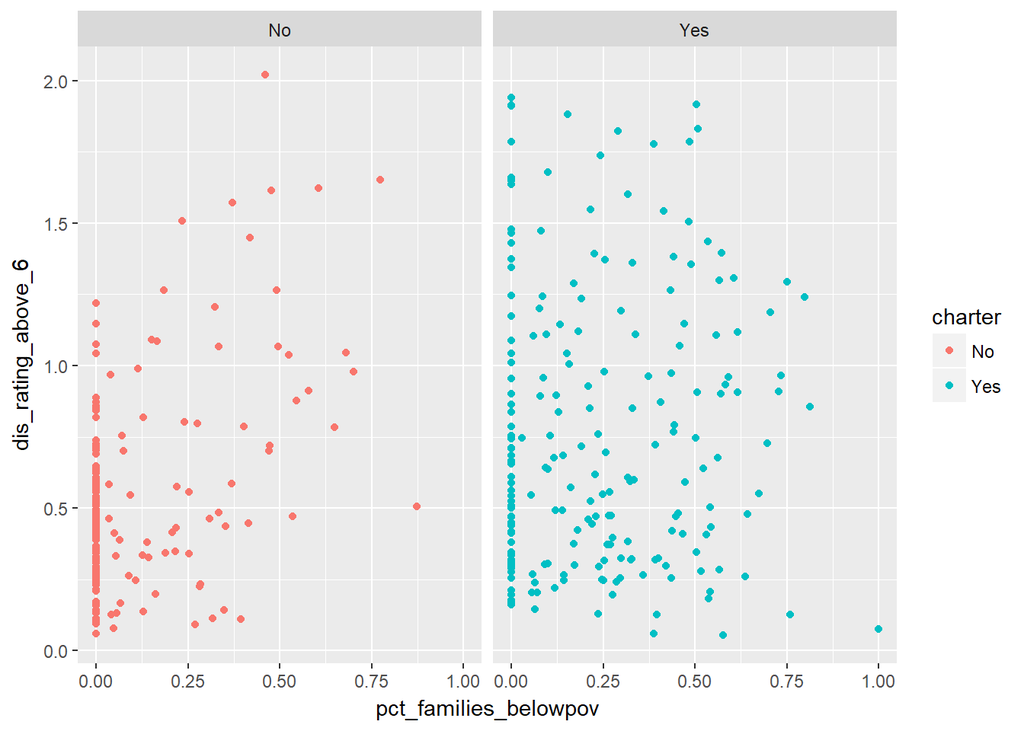

```r
ggplot(data_w_kids, aes(x=pct_families_belowpov, y=dis_rating_above_6, color=charter)) + geom_point() + facet_grid(. ~ charter)
```

The relationship seems stronger if you filter out charter schools.

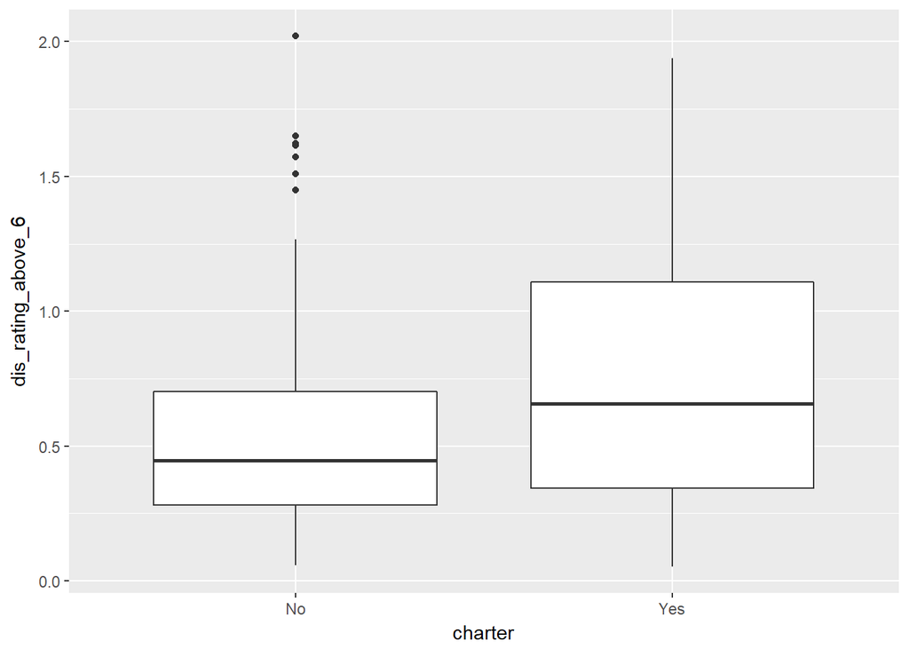

```r
ggplot(data_w_kids, aes(x=charter, y=dis_rating_above_6)) + geom_boxplot()
```

More variation in distance to a charter school.

#### Explore relationship between school distance and race

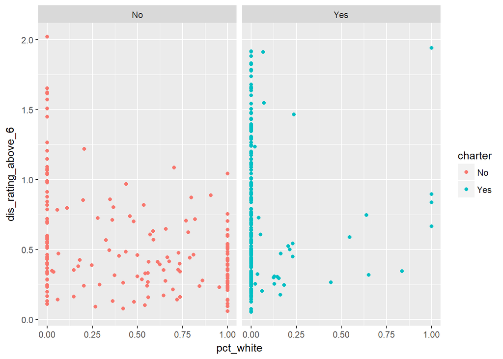

```r
ggplot(data_w_kids, aes(x=pct_white, y=dis_rating_above_6, color=charter)) + geom_point() + facet_grid(. ~ charter)
```

Few white children have to travel more than 1 mile to get to a good school.

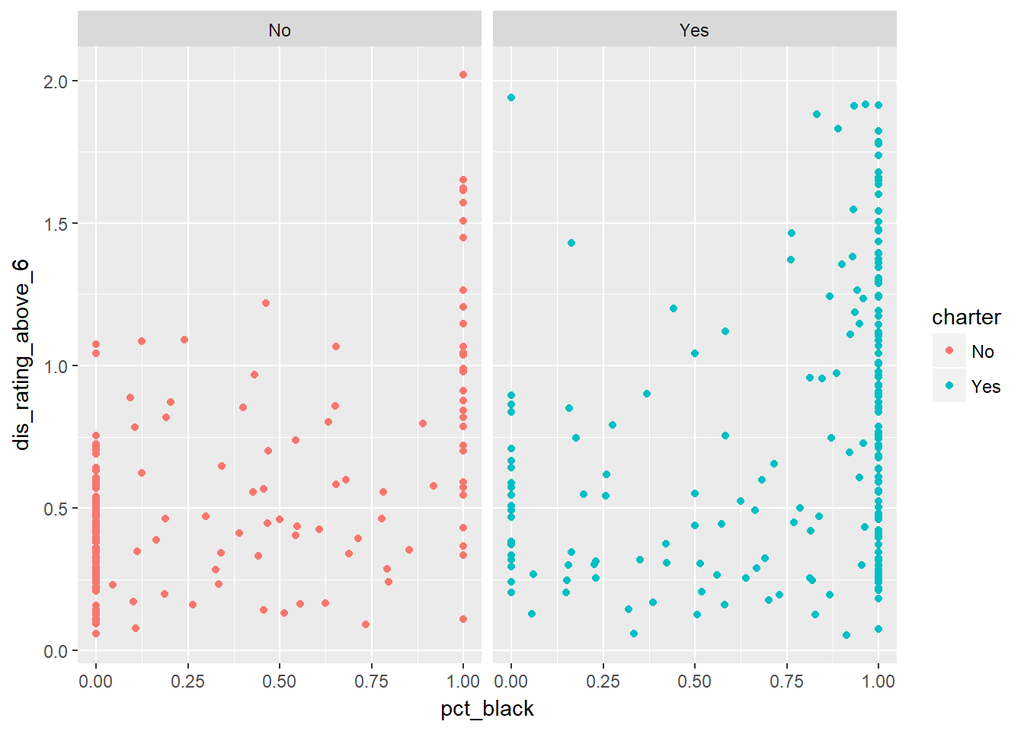

```r
ggplot(data_w_kids, aes(x=pct_black, y=dis_rating_above_6, color=charter)) + geom_point() + facet_grid(. ~ charter)
```

More variability in distance among blocks with many black children compared to white children.

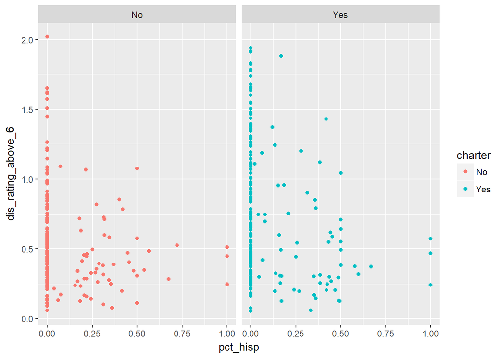

```r
ggplot(data_w_kids, aes(x=pct_hisp, y=dis_rating_above_6, color=charter)) + geom_point() + facet_grid(. ~ charter)
```

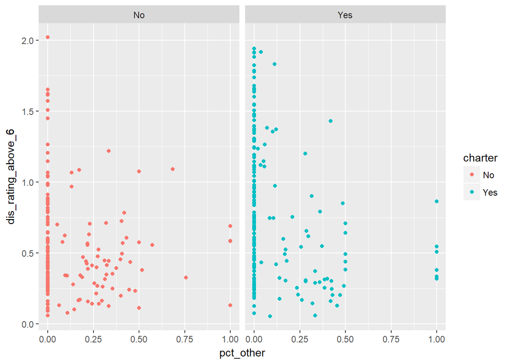

```r
ggplot(data_w_kids, aes(x=pct_other, y=dis_rating_above_6, color=charter)) + geom_point() + facet_grid(. ~ charter)
```

#### Explore relationship between race and poverty

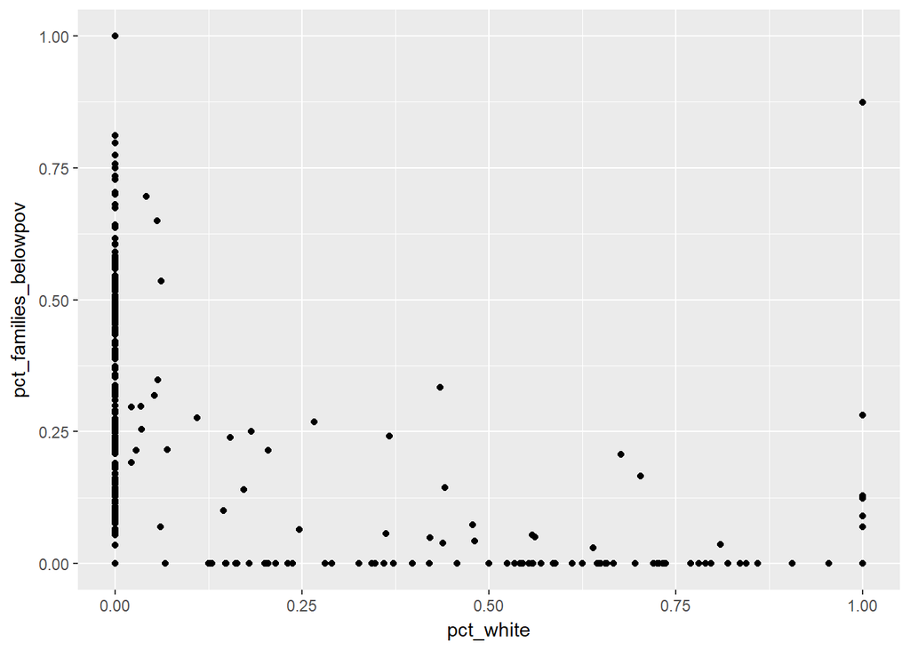

```r
ggplot(data_w_kids, aes(x=pct_white, y=pct_families_belowpov)) + geom_point()
```

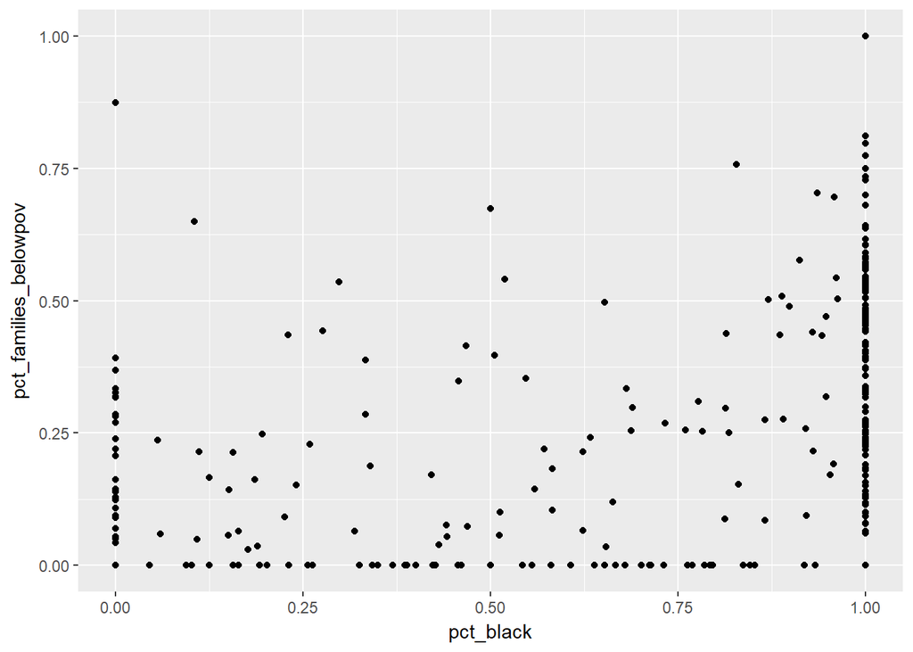

```r
ggplot(data_w_kids, aes(x=pct_black, y=pct_families_belowpov)) + geom_point()
```

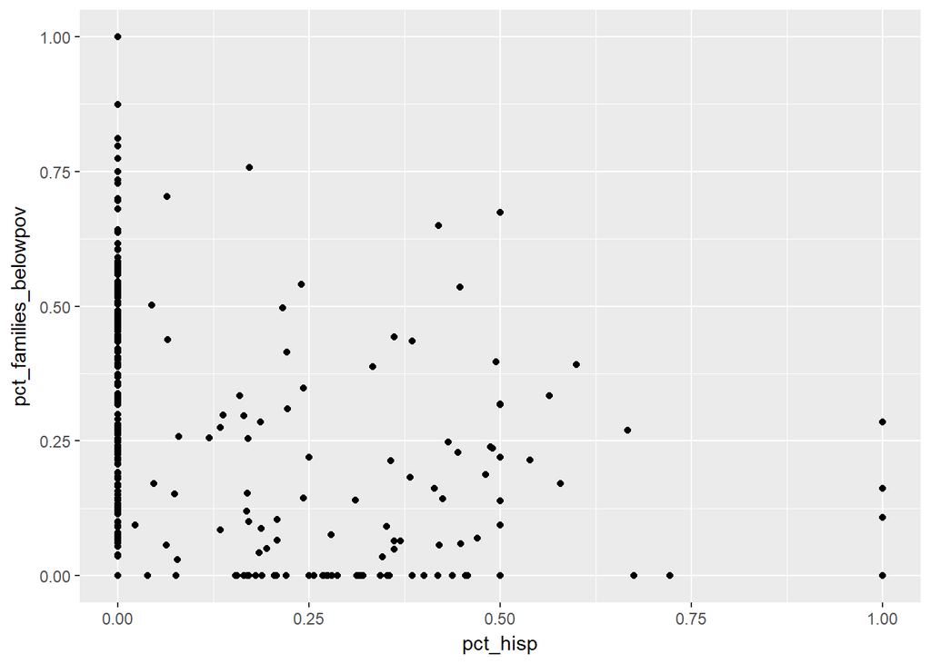

```r
ggplot(data_w_kids, aes(x=pct_hisp, y=pct_families_belowpov)) + geom_point()
```

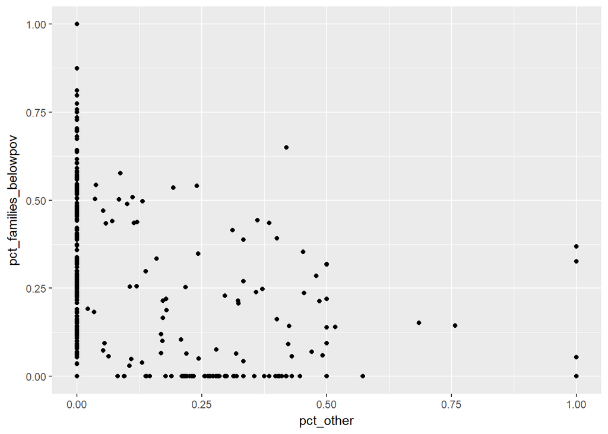

```r
ggplot(data_w_kids, aes(x=pct_other, y=pct_families_belowpov)) + geom_point()
```

Definitely seems to be a relationship between race and poverty.

Story seems to be that poorer, minority kids tend to live farther than their wealthier, white peers do from good schools.

### Prep Data for Plotting:

```r
final <- data_w_kids[,c("id", "geography", "dis_rating_above_6", "school_name", "pct_families_belowpov", "total_grade_1_5",
                        "pct_white", "pct_black", "pct_hisp", "pct_other")]

# Add an indicator for blocks where the share of families in poverty exceeds the district-wide poverty rate (18.6%)
final$high_poverty <- 0
final$high_poverty[final$pct_families_belowpov > 0.186] <- 1

write.csv(final, "data_for_plot.csv", row.names = FALSE)
```